# PG2

25 de noviembre de 2022

# Estudio de Mercado de la Comunidad K-POP en Lima Metropolitana

# Introducción

## Relevancia

Según estudios y datos obtenidos de la Federación Internacional de la Industria Fonográfica (Ifpi) la industria musical de Corea del Sur ha logrado superar a otros países ocupando el puesto 5 a nivel mundial en 2005. Así, el Perú es uno de los países que se suman a la acogida de este género en los últimos años. Es posible conocer a partir de estudios anteriores la preferencia por determinados grupos, por ejemplo, BTS concentra el 93% de menciones en redes sociales en Perú, seguidamente existe una tendencia hacia la banda femenina BLACK PINK. Además,por lo general, la comunidad K-Pop que impone estas tendencias está conformada por jóvenes que a su vez forman parte de fan bases para conseguir visibilidad masiva en redes (Fernando Vega, 2019).

La relevancia de este proyecto radica en el hecho que el K-POP es uno de los géneros más acogidos actualmente. En 2019 los ingresos obtenidos a partir de streaming de este género ascendieron en un 47%. En nuestro país el K-Pop también se encuentra en apogeo, Perú aparece en la posición 11 y se ha convertido en el tercer país en América Latina con mayor contenido relacionado a este género musical en redes sociales (Twitter). Además, por lo general, los fans del K-POP tienen la tendencia de interesarse más por la cultura asiática. Por tanto, el presente tema resulta relevante ya que mediante un estudio de mercado será posible conocer la demanda que ofrece esta comunidad para el surgimiento de emprendimientos asociados al género, asi como entender el perfil de los seguidores del K-POP permitirá conocer por qué productos se inclina este público para una mejor oferta.

## Planificación

Hemos representado las actividades que hemos realizado cada semana mediante un diagrama de Gantt:

```r
#Especificamos  las Actividades que realizamos

data_1 <- data.frame(Actividad = c("Plantear propuestas", "Identificación de las variables", "Recolección de datos", "Descripción de variables mediante descriptores", "Identificación del comportamiento de las variables", "Identificación de los patrones en las variables", "Reconocimiento de relaciones entre variables", "Validación de dependencias", "Postulación de hipótesis","Inferencia del comportamiento de las variables","Conclusiones e interpretaciones","Entrega de la P1","Plantemiento de Objetivos","Planteamiento de las Variables para las probabilidades","Planteamiento de Problemas Probabilisticos","Resolucion de Problemas Probabilisticos","Conclusiones respecto a los resultados obtenidos","Entrega de la P2"),

#Especificamos las semanas en las cuales se trabajo cada actividad
start = c(1, 3, 5, 6,6,6,6,6,6,7,7,7,9,10,11,12,13,14),
end = c(3, 5, 7, 7,7,7,7,7,7,8,8,8,10,11,12,13,14,15),

#Especificamos a que entrega pertenece
shift_type = c('PG0', 'PG0', 'PG1', 'PG1','PG1','PG1','PG1','PG1','PG1','PG1','PG1','PG1','PG2','PG2','PG2','PG2','PG2','PG2')
)
data_1
```

| Actividad | start | end | shift_type |
| --- | --- | --- | --- |
| Plantear propuestas | 1 | 3 | PG0 |
| Identificación de las variables | 3 | 5 | PG0 |
| Recolección de datos | 5 | 7 | PG1 |
| Descripción de variables mediante descriptores | 6 | 7 | PG1 |
| Identificación del comportamiento de las variables | 6 | 7 | PG1 |
| Identificación de los patrones en las variables | 6 | 7 | PG1 |
| Reconocimiento de relaciones entre variables | 6 | 7 | PG1 |
| Validación de dependencias | 6 | 7 | PG1 |
| Postulación de hipótesis | 6 | 7 | PG1 |
| Inferencia del comportamiento de las variables | 7 | 8 | PG1 |

[output cut: 8 more lines]

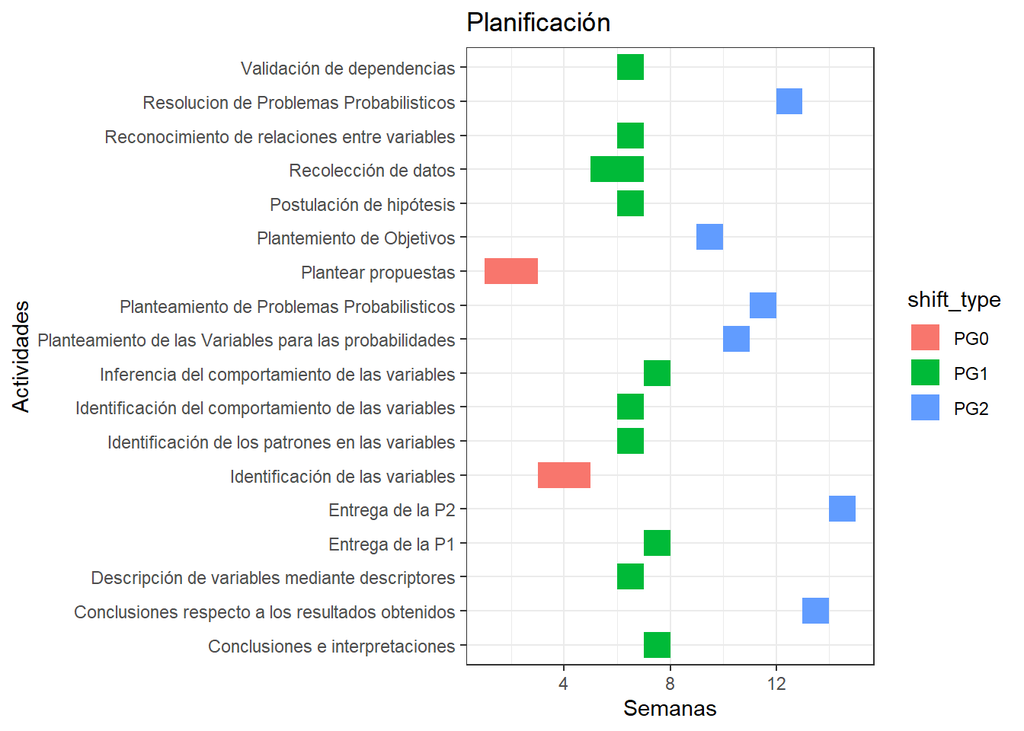

```r
#instalamos y cargamos el ggplot2
if(!require(ggplot2)){install.packages('ggplot2')}
#Creamos el diagrams de Gantt, donde visualizaremos el comienzo y termino de cada actividad.
ggplot(data_1, aes(x=start, xend=end, y=Actividad, yend=Actividad, color=shift_type)) +
  theme_bw()+
  geom_segment(size=6) +
  labs(title='Planificación', x='Semanas', y='Actividades')
```

## Datos

### Proceso de recolección

Realizamos el proceso de recoleccion de datos mediante una encuesta realizada en google forms,esta encuesta fue difundida por redes sociales entre las cuales se encuentran Grupos de Whatsapp, Grupos de Telegram y Facebook orientados al género del Kpop en Lima, elegimos este medio debido a que las redes sociales son el medio de comunicación con mayor alcance en la actualidad.Al ver que las encuestas no subian de manera significativa, decidimos incluir un premio via sorteo, para las personas que rellenen nuestra encuesta.

[figure not shown]

**Figura 1:Encuesta**

[figure not shown]

**Figura 2:Mensaje Promocional**

Despues de aplicar estas dos estrategias y ver que las encuestas tampoco subian, decidimos realizar el proceso de recoleccion de manera presencial, el cual se desarrollo en la universidad UTEC, en donde ofrecimos dulces a las estudiantes que escaneen el codigo QR que los redirigia a nuestra encuesta.

[figure not shown]

**Figura 3: Codigo QR**

### Poblacion de Estudio

La población en estudio se encuentra delimitada por la comunidad seguidora de K-Pop en Lima Metropolitana, Perú.

### Tipo de muestreo

Se realizó un muestreo por conveniencia, y por lo tanto la muestra no es representativa, pues no hubo de por medio un proceso aleatorio para la selección de la muestra. La mayoría de las personas que conforman la muestra son estudiantes de UTEC (seguidores del género) que se encontraban dispuestos a completar la encuesta, en consecuencia existe un sesgo de selección.

## Variables

Explicamos cada variable presente en el estudio mediante la siguiente tabla:

| Pregunta | Variable | Tipo de variable | Restricciones |
| --- | --- | --- | --- |
| ¿Sigues el género del K-pop? | Seguidor | Categórica Nominal | Sí y No |
| ¿Cuál es tu género? | Genero | Categórica Nominal | Femenino y Masculino |
| ¿Cuál es tu edad? | Edad | Numérica Discreta | Número entero mayor a 0 |
| ¿Desde hace cuántos años sigue el K-Pop? | Seguimiento | Numérica Discreta | Número entero mayor a 0 |
| ¿Cuál es su grupo favorito? | Grupo_Favorito | Categórica Nominal | Ninguna |
| ¿Cuál es el género de los integrantes de tu grupo favorito? | Genero_Grupo | Categórica Nominal | Masculino y Femenino |
| ¿Formas parte de un fanclub? | FanClub | Categórica Nominal | Si y No |
| ¿En qué lugar sueles encontrarte con otros fans? | Lugar_Fanclub | Categórica Nominal | Ninguna |
| ¿Qué medio sueles utilizar con mayor frecuencia para informarte del mundo del K-pop? | Medio_informacion | Categórica Nominal | Ninguna |
| ¿Cuánto tiempo al día le dedicas a informarte sobre el grupo o artista que sigues? | Tiempo_dedicado | Numérica continua | Número mayor a 0 |
| ¿Qué artículos relacionados al K-Pop compras o comprarías? | Gusto_productos | Categórica Nominal | Ninguna |
| ¿Cuánto de dinero (S/.) estás dispuesto a pagar por un producto relacionado al K-Pop? | Presupuesto_producto | Numérica continua | Ninguna |
| ¿Usualmente, mediante qué medio adquieres estos artículos? | Medios_adquisicion | Categórica Nominal | Tienda en línea y tienda física |
| ¿Cuán importante consideras el K-POP en tu vida? | Importancia_Kpop | Numérica Discreta | Número natural entre 1 y 5 |
| ¿Alguna vez te haz sentido excluido por formar parte de esta comunidad? | Exclucion | Categórica nominal | Si y No |
| ¿Qué te motiva a consumir contenido de K-pop? | Motivacion | Categórica Nominal | Ninguna |
| ¿Qué sientes al escuchar K-pop? | Sentimiento_Kpop | Categórica Nominal | Ninguna |

## Limpieza de Datos

1. Instalamos y cargamos las librerias :

Cargamos las librerias:

```r
library(readr)
library(dplyr)
library(VennDiagram)
```

```r
library(fastGraph)
```

Luego cargamos el archivo en formato cvs

```r
Kp <- read_csv("Estudio de mercado sobre la comunidad Seguidora de K-Pop (respuestas) - Respuestas de formulario 1(1).csv")
```

2. Analisis de los datos

Ahora vemos el numero de observaciones y variables de nuestra data antes de pasar por la limpieza de datos.

```r
nrow(Kp)
```

```
## [1] 307
```

```r
ncol(Kp)
```

```
## [1] 19
```

```r
dim(Kp)
```

```
## [1] 307  19
```

Ahora veremos los tipos de variables

```r
str(Kp)
```

```
## spc_tbl_ [307 x 19] (S3: spec_tbl_df/tbl_df/tbl/data.frame)
##  $ Marca temporal                                                                                                                  : chr [1:307] "19/09/2022 21:10:27" "19/09/2022 21:16:01" "19/09/2022 21:17:30" "19/09/2022 21:26:26" ...
##  $ 1. ¿Sigues el genero del K-pop?                                                                                                 : chr [1:307] "No" "Sí" "Sí" "Sí" ...
##  $ 2. ¿Cuál es tu género? Coloque el que figure en su DNI.                                                                         : chr [1:307] NA "Femenino" "Femenino" "Femenino" ...
##  $ 3. Edad (descrita en años):                                                                                                     : num [1:307] NA 16 19 15 NA NA 16 15 14 16 ...
##  $ 4. ¿Desde hace cuantos años sigues el K-POP ?  Ejemplo: 10                                                                      : num [1:307] NA 1 12 3 NA NA 12 12 2 5 ...
##  $ 5. ¿Cuál es tu grupo favorito? Especificar solo uno. Ejemplo: Stray Kids                                                        : chr [1:307] NA "BTS" "Bangtan" "NCT" ...
##  $ 6. Los integrantes del grupo que sigues son de género:                                                                          : chr [1:307] NA "Masculino" "Masculino" "Masculino" ...
##  $ 7. ¿Formas parte de un fanclub?
##
## Fanclub: Organización de fans que realizan actividades para difundir el grupo/idol que sigue.: chr [1:307] NA "Si" "No" "No" ...
##  $ 8. ¿En que lugar sueles encontrarte con otros fans?                                                                             : chr [1:307] NA "Campo de Marte" "Campo de Marte, Fiestas tematicas de K-POP, En Cines, En Cafes" "No me reúno :\"(" ...
##  $ 9. ¿Qué medio sueles utilizar con mayor frecuencia para informarte del mundo del K-pop?                                         : chr [1:307] NA "Páginas Web, Redes sociales (Facebook, Twitter,Telegram,Tiktok,etc.), Youtube, Círculo social" "Páginas Web, Redes sociales (Facebook, Twitter,Teleg…
##  $ 10. ¿Cuánto tiempo al día le dedicas a informarte sobre el grupo o artista que sigues? Responder en horas. Ejemplo: 5           : num [1:307] NA 3 1 4 NA NA 1 1 NA 3 ...
##  $ 11. ¿Qué artículos relacionados al K-Pop compras o comprarías?                                                                  : chr [1:307] NA "Peluches, Albumes, PhotoCards, CD, Ligth stick" "Peluches, Albumes, PhotoCards" "Peluches, Albumes, PhotoCards, CD, Ropa, Ligth stick" ...
##  $ 12. ¿Cuánto de dinero (S/.) estás dispuesto a pagar por un producto relacionado al K-Pop?                                       : num [1:307] NA 300 150 100 NA NA 200 150 100 100 ...
##  $ 13. ¿Usualmente, mediante qué medio adquieres estos artículos?                                                                  : chr [1:307] NA "Tiendas físicas" "Tiendas en línea, Tiendas físicas" "Tiendas en línea" ...
##  $ 15. ¿Cuán importante consideras el K-POP en tu vida?                                                                            : num [1:307] NA 5 1 5 NA NA 4 3 2 5 ...
##  $ 16. ¿Alguna vez te haz sentido excluido por formar parte de esta comunidad?                                                     : chr [1:307] NA "Sí" "Sí" "Sí" ...
##  $ 17. ¿Qué te motiva a consumir contenido de K-pop?                                                                               : chr [1:307] NA "Contenido musical, Personalidad de los Idols, Atracción por los Idols" "Contenido musical" "Contenido musical, Personalidad de los Idols, Atracción …
##  $ 18. ¿Qué sientes al escuchar K-pop?                                                                                             : chr [1:307] NA "Tranquilidad, Alegria, Felicidad, Reconfortante, Comprención" "Tranquilidad, Alegria, Tristeza, Felicidad, Reconfortante, Comprención" "Tranquilidad…
##  $ Dirección de correo electrónico                                                                                                 : chr [1:307] NA NA NA NA ...
##  - attr(*, "spec")=
##   .. cols(
##   ..   `Marca temporal` = col_character(),
##   ..   `1. ¿Sigues el genero del K-pop?` = col_character(),
##   ..   `2. ¿Cuál es tu género? Coloque el que figure en su DNI.` = col_character(),
##   ..   `3. Edad (descrita en años):` = col_double(),
##   ..   `4. ¿Desde hace cuantos años sigues el K-POP ?  Ejemplo: 10` = col_double(),
##   ..   `5. ¿Cuál es tu grupo favorito? Especificar solo uno. Ejemplo: Stray Kids` = col_character(),
##   ..   `6. Los integrantes del grupo que sigues son de género:` = col_character(),
##   ..   `7. ¿Formas parte de un fanclub?
##   ..
##   .. Fanclub: Organización de fans que realizan actividades para difundir el grupo/idol que sigue.` = col_character(),
##   ..   `8. ¿En que lugar sueles encontrarte con otros fans?` = col_character(),
##   ..   `9. ¿Qué medio sueles utilizar con mayor frecuencia para informarte del mundo del K-pop?` = col_character(),
##   ..   `10. ¿Cuánto tiempo al día le dedicas a informarte sobre el grupo o artista que sigues? Responder en horas. Ejemplo: 5` = col_double(),
##   ..   `11. ¿Qué artículos relacionados al K-Pop compras o comprarías?` = col_character(),
##   ..   `12. ¿Cuánto de dinero (S/.) estás dispuesto a pagar por un producto relacionado al K-Pop?` = col_double(),
##   ..   `13. ¿Usualmente, mediante qué medio adquieres estos artículos?` = col_character(),
##   ..   `15. ¿Cuán importante consideras el K-POP en tu vida?` = col_double(),
##   ..   `16. ¿Alguna vez te haz sentido excluido por formar parte de esta comunidad?` = col_character(),
##   ..   `17. ¿Qué te motiva a consumir contenido de K-pop?` = col_character(),
##   ..   `18. ¿Qué sientes al escuchar K-pop?` = col_character(),
##   ..   `Dirección de correo electrónico` = col_character()
##   .. )
##  - attr(*, "problems")=<externalptr>
```

```r
summary(Kp)
```

```
##  Marca temporal     1. ¿Sigues el genero del K-pop?
##  Length:307         Length:307
##  Class :character   Class :character
##  Mode  :character   Mode  :character
##
##
##
##
##  2. ¿Cuál es tu género? Coloque el que figure en su DNI.
##  Length:307
##  Class :character
##  Mode  :character
##
##
##
##
##  3. Edad (descrita en años):
##  Min.   : 6.00
##  1st Qu.:17.00
##  Median :19.00
##  Mean   :18.45
##  3rd Qu.:20.00
##  Max.   :26.00
##  NA's   :96
##  4. ¿Desde hace cuantos años sigues el K-POP ?  Ejemplo: 10
##  Min.   : 0.000
##  1st Qu.: 2.000
##  Median : 4.000
##  Mean   : 5.517
##  3rd Qu.: 7.000
##  Max.   :19.000
##  NA's   :96
##  5. ¿Cuál es tu grupo favorito? Especificar solo uno. Ejemplo: Stray Kids
##  Length:307
##  Class :character
##  Mode  :character
##
##
##
##
```

[output cut: 81 more lines]

```
##  Length:307
##  Class :character
##  Mode  :character
##
##
##
##
##  18. ¿Qué sientes al escuchar K-pop? Dirección de correo electrónico
##  Length:307                          Length:307
##  Class :character                    Class :character
##  Mode  :character                    Mode  :character
##
##
##
##
```

Observamos que solo tenemos 5 variables numericas y 14 variables categoricas, sin embargo para este estudio solo utilizaremos 12 variables categoricas

Pasamos a ver cuantas cuantas casillas incompletas y datos faltantes hay en el dataframe

```r
sum(is.na(Kp))
```

```
## [1] 1605
```

```r
sum(!complete.cases(Kp))
```

```
## [1] 150
```

3. Renombrando las variables y limpiando la tabla

Previo a empezar con la limpieza de datos renombraremos el nombre de los datos usando el comando names observamos el nombre de cada variable y la renombraremos a una que nos sea mas facil de manipular

```r
names(Kp)
```

```
##  [1] "Marca temporal"
##  [2] "1. ¿Sigues el genero del K-pop?"
##  [3] "2. ¿Cuál es tu género? Coloque el que figure en su DNI."
##  [4] "3. Edad (descrita en años):"
##  [5] "4. ¿Desde hace cuantos años sigues el K-POP ?  Ejemplo: 10"
##  [6] "5. ¿Cuál es tu grupo favorito? Especificar solo uno. Ejemplo: Stray Kids"
##  [7] "6. Los integrantes del grupo que sigues son de género:"
##  [8] "7. ¿Formas parte de un fanclub?\n\nFanclub: Organización de fans que realizan actividades para difundir el grupo/idol que sigue."
##  [9] "8. ¿En que lugar sueles encontrarte con otros fans?"
## [10] "9. ¿Qué medio sueles utilizar con mayor frecuencia para informarte del mundo del K-pop?"
## [11] "10. ¿Cuánto tiempo al día le dedicas a informarte sobre el grupo o artista que sigues? Responder en horas. Ejemplo: 5"
## [12] "11. ¿Qué artículos relacionados al K-Pop compras o comprarías?"
## [13] "12. ¿Cuánto de dinero (S/.) estás dispuesto a pagar por un producto relacionado al K-Pop?"
## [14] "13. ¿Usualmente, mediante qué medio adquieres estos artículos?"
## [15] "15. ¿Cuán importante consideras el K-POP en tu vida?"
## [16] "16. ¿Alguna vez te haz sentido excluido por formar parte de esta comunidad?"
## [17] "17. ¿Qué te motiva a consumir contenido de K-pop?"
## [18] "18. ¿Qué sientes al escuchar K-pop?"
## [19] "Dirección de correo electrónico"
```

**NO DEBE TENER** tildes, caracteres especiales y espacios Para poder comparar nuestro avance crearemos un clon de nuestra base de datos

```r
Kpp = Kp
```

Utilizando el comando rename cambiamos nuestras variables

```r
Kpp <- rename(Kpp,marca="Marca temporal", Seguidor = '1. ¿Sigues el genero del K-pop?', Genero = '2. ¿Cuál es tu género? Coloque el que figure en su DNI.', Edad='3. Edad (descrita en años):', Seguimiento= '4. ¿Desde hace cuantos años sigues el K-POP ?  Ejemplo: 10', GrupoFav = '5. ¿Cuál es tu grupo favorito? Especificar solo uno. Ejemplo: Stray Kids', Genero_Grupo = '6. Los integrantes del grupo que sigues son de género:' , FanClub = '7. ¿Formas parte de un fanclub?\n\nFanclub: Organización de fans que realizan actividades para difundir el grupo/idol que sigue.', Lugar_FanClub = '8. ¿En que lugar sueles encontrarte con otros fans?',Medio_infor = '9. ¿Qué medio sueles utilizar con mayor frecuencia para informarte del mundo del K-pop?', Tiempo_dedicado = '10. ¿Cuánto tiempo al día le dedicas a informarte sobre el grupo o artista que sigues? Responder en horas. Ejemplo: 5', Gusto_productos = '11. ¿Qué artículos relacionados al K-Pop compras o comprarías?',Presupuesto_prod = '12. ¿Cuánto de dinero (S/.) estás dispuesto a pagar por un producto relacionado al K-Pop?',Medios_adquisicion = '13. ¿Usualmente, mediante qué medio adquieres estos artículos?', Importancia = '15. ¿Cuán importante consideras el K-POP en tu vida?',Exclusion = '16. ¿Alguna vez te haz sentido excluido por formar parte de esta comunidad?', Motivacion = '17. ¿Qué te motiva a consumir contenido de K-pop?',Sentimiento_Kpop='18. ¿Qué sientes al escuchar K-pop?',marca='Marca temporal',direccion='Dirección de correo electrónico')
```

```r
names(Kpp)
```

```
##  [1] "marca"              "Seguidor"           "Genero"
##  [4] "Edad"               "Seguimiento"        "GrupoFav"
##  [7] "Genero_Grupo"       "FanClub"            "Lugar_FanClub"
## [10] "Medio_infor"        "Tiempo_dedicado"    "Gusto_productos"
## [13] "Presupuesto_prod"   "Medios_adquisicion" "Importancia"
## [16] "Exclusion"          "Motivacion"         "Sentimiento_Kpop"
## [19] "direccion"
```

Ahora solo eliminamos la primera y ultima columnas, cuyos datos no son de importancia para este estudio.

```r
Kpp <- select(Kpp, -marca, -direccion)
```

Por ultimo borramos todos los casos incompletos.

```r
Kpp <- na.omit(Kpp)
```

4. correcion de variables

Ahora que la tabla esta lista podemos hacer una limpieza por variable.

4.1. Grupos

```r
unique(Kpp$GrupoFav)
```

```
##  [1] "BTS"
##  [2] "Bangtan"
##  [3] "NCT"
##  [4] "skz y ive"
##  [5] "Mi grupo favorito era BTS."
##  [6] "Bts"
##  [7] "Blackpink"
##  [8] "Twice"
##  [9] "Straykids"
## [10] "Bts, the rose, momoland, mamaoo, VAV, Stray kids, etc"
## [11] "Enhypen"
## [12] "Stray Kids"
## [13] "ONEUS"
## [14] "EXO"
## [15] "ATEEZ"
```

[output cut: 46 more lines]

No esta correcto, procedemos a limpiar, pero antes observamos que hay un grupo que no corresponde a nuestro estudio.

```r
filter(Kpp, GrupoFav=="Neffex")
```

| Seguidor | Genero | Edad | Seguimiento | GrupoFav | Genero_Grupo | FanClub | Lugar_FanClub | Medio_infor | Tiempo_dedicado | Gusto_productos | Presupuesto_prod | Medios_adquisicion | Importancia | Exclusion | Motivacion | Sentimiento_Kpop |
| --- | --- | --- | --- | --- | --- | --- | --- | --- | --- | --- | --- | --- | --- | --- | --- | --- |
| Sí | Masculino | 19 | 0 | Neffex | Masculino | No | No asisto a reuniones presenciales | Televisión, Páginas Web, Redes sociales (Facebook, Twitter,Telegram,Tiktok,etc.), Youtube | 5 | Peluches, Albumes, Ropa | 100 | Tiendas físicas | 1 | No | Contenido musical, Personalidad de los Idols, Influencia de terceros | Tranquilidad, Asombro, Alegria |

```r
which(Kpp$GrupoFav=="Neffex")
```

```
## [1] 177
```

Ahora que sabemos la fila procedemos a borrarla

```r
Kpop <- Kpp[-177,]
```

Procedemos a limpiar las respuestas.

```r
Kpop %>% mutate(GrupoFav=
        ifelse(GrupoFav %in% c("BTS","Bangtan", "Mi grupo favorito era BTS.","Bts","Bts, the rose, momoland, mamaoo, VAV, Stray kids, etc","BTS,EXO",
"Bangtan Sonyeondan (BTS)💜","Bts pave the way","bTsS","BTS💜","Bts, txt, ,ateez, itzy, stray kids,","bts","BTS, EXO, STRAY KIDS, TXT"), "BTS",
        ifelse(GrupoFav == "skz y ive" ,"SKZ",
        ifelse(GrupoFav %in% c("Blackpink","Black pinck","BLACKPINK","BlackPink","Black Pink","Black pink - f(x)","black pink","Black pink","Blacpink"),"BlackPink",
        ifelse(GrupoFav %in% c("Twice","TWICE", "twice","Twice y Red Velvet"),"Twice",
        ifelse(GrupoFav %in% c("Straykids","Stray Kids","STRAY KIDS","Stray kids"),"StrayKids",
        ifelse(GrupoFav == "ONEUS","Oneus",
        ifelse(GrupoFav %in% c("EXO","Exo"),"EXO",
        ifelse(GrupoFav == "ATEEZ","Ateez",
        ifelse(GrupoFav %in% c("Bug bang","Big bang","Big Bang"),"BigBang",
        ifelse(GrupoFav %in% c("Red Velvet","Red velvet"),"RedVelvet",
        ifelse(GrupoFav %in% c("Tomorrow by together ,bts" ,"TXT","Txt"),"TXT",
        ifelse(GrupoFav == "The Rose","TheRose",
        ifelse(GrupoFav == "iKON","Ikon",
        ifelse(GrupoFav %in% c("Shinee" ,"SHINee"),"Shinee",
        ifelse(GrupoFav == "Girls Generation","GirlsGeneration",GrupoFav )))))))))))))))) -> Kpop
```

4.2 Lugar

```r
unique(Kpop$Lugar_FanClub)
```

```
##  [1] "Campo de Marte"
##  [2] "Campo de Marte, Fiestas tematicas de K-POP, En Cines, En Cafes"
##  [3] "No me reúno :\"("
##  [4] "no me dejan ir a juntas ☹️"
##  [5] "En Cines"
##  [6] "En el colegio"
##  [7] "En ningún lugar"
##  [8] "Campo de Marte, Fiestas tematicas de K-POP"
##  [9] "No pertenezco a un club de fans"
## [10] "Fiestas tematicas de K-POP"
## [11] "En Cines, En Cafes"
## [12] "Campo de Marte, En Cafes"
## [13] "Mediante redes sociales"
## [14] "Fiestas tematicas de K-POP, En Cafes"
## [15] "Campo de Marte, En centros comerciales"
```

[output cut: 35 more lines]

Limpiando la variable “lugar”

```r
Kpop %>% mutate(Lugar_FanClub=
        ifelse(Lugar_FanClub %in% c("No me reúno :\"(" ,"no me dejan ir a juntas ☹️","En ningún lugar","No pertenezco a un club de fans","Mediante redes sociales","No asisto a reuniones presenciales","En Cines, No asisto a reuniones presenciales","Campo de Marte, Fiestas tematicas de K-POP, En Cines, En Cafes, En centros comerciales, No asisto a reuniones presenciales, Alameda 28 de Julio","No asisto a reuniones presenciales, Alameda 28 de Julio","En Cafes, No asisto a reuniones presenciales"),"No asisto a reuniones presenciales",Lugar_FanClub
               ))->Kpop
```

exportamos a formato excel nuestra base de datos

```r
library(openxlsx)
write.xlsx(Kpop,"Kpop.xlsx")
```

```r
summary(Kpop)
```

```
##    Seguidor            Genero               Edad        Seguimiento
##  Length:209         Length:209         Min.   : 6.00   Min.   : 0.00
##  Class :character   Class :character   1st Qu.:17.00   1st Qu.: 2.00
##  Mode  :character   Mode  :character   Median :19.00   Median : 4.00
##                                        Mean   :18.47   Mean   : 5.56
##                                        3rd Qu.:20.00   3rd Qu.: 7.00
##                                        Max.   :26.00   Max.   :19.00
##    GrupoFav         Genero_Grupo         FanClub          Lugar_FanClub
##  Length:209         Length:209         Length:209         Length:209
##  Class :character   Class :character   Class :character   Class :character
##  Mode  :character   Mode  :character   Mode  :character   Mode  :character
##
##
##
##  Medio_infor        Tiempo_dedicado  Gusto_productos    Presupuesto_prod
##  Length:209         Min.   : 0.000   Length:209         Min.   :     0.0
##  Class :character   1st Qu.: 1.000   Class :character   1st Qu.:    50.0
##  Mode  :character   Median : 1.000   Mode  :character   Median :    80.0
##                     Mean   : 2.175                      Mean   :   618.1
##                     3rd Qu.: 3.000                      3rd Qu.:   200.0
##                     Max.   :12.000                      Max.   :100000.0
##  Medios_adquisicion  Importancia     Exclusion          Motivacion
##  Length:209         Min.   :1.000   Length:209         Length:209
##  Class :character   1st Qu.:3.000   Class :character   Class :character
##  Mode  :character   Median :4.000   Mode  :character   Mode  :character
##                     Mean   :3.699
##                     3rd Qu.:5.000
##                     Max.   :5.000
##  Sentimiento_Kpop
##  Length:209
##  Class :character
##  Mode  :character
##
##
##
```

Luego de dividir en columnas las variables con opciones multiples tenemos la siguiente base de datos_limpia.

```r
KP <- read.csv("Kpop_final.csv")
```

```r
summary(KP)
```

```
##    Seguidor            Genero               Edad        Seguimiento
##  Length:209         Length:209         Min.   : 6.00   Min.   : 0.00
##  Class :character   Class :character   1st Qu.:17.00   1st Qu.: 2.00
##  Mode  :character   Mode  :character   Median :19.00   Median : 4.00
##                                        Mean   :18.47   Mean   : 5.56
##                                        3rd Qu.:20.00   3rd Qu.: 7.00
##                                        Max.   :26.00   Max.   :19.00
##    GrupoFav         Genero_Grupo         FanClub          Campo.de.Marte
##  Length:209         Length:209         Length:209         Length:209
##  Class :character   Class :character   Class :character   Class :character
##  Mode  :character   Mode  :character   Mode  :character   Mode  :character
##
##
##
##    Fiestas             Cines               Cafe           CentroComercial
##  Length:209         Length:209         Length:209         Length:209
##  Class :character   Class :character   Class :character   Class :character
##  Mode  :character   Mode  :character   Mode  :character   Mode  :character
##
##
##
##   Alameda28          No.asiste          television         PaginasWeb
##  Length:209         Length:209         Length:209         Length:209
##  Class :character   Class :character   Class :character   Class :character
##  Mode  :character   Mode  :character   Mode  :character   Mode  :character
##
##
##
##     Redes             youtube             radio             circulo
##  Length:209         Length:209         Length:209         Length:209
##  Class :character   Class :character   Class :character   Class :character
##  Mode  :character   Mode  :character   Mode  :character   Mode  :character
##
##
##
##    paneles          Tiempo_dedicado    Peluches           Albumes
##  Length:209         Min.   : 0.000   Length:209         Length:209
##  Class :character   1st Qu.: 1.000   Class :character   Class :character
##  Mode  :character   Median : 1.000   Mode  :character   Mode  :character
##                     Mean   : 2.201
```

[output cut: 29 more lines]

```
##
##   Felicidad         Reconfortante      ComprensiÃ³n         Tristeza
##  Length:209         Length:209         Length:209         Length:209
##  Class :character   Class :character   Class :character   Class :character
##  Mode  :character   Mode  :character   Mode  :character   Mode  :character
##
##
##
##    Asombro           otro_senti
##  Length:209         Length:209
##  Class :character   Class :character
##  Mode  :character   Mode  :character
##
##
##
```

## Análisis Descriptivo

Antes de empezar a hacer el analisis planteamos como objetivos:

### Objetivo General

Realizar un estudio de mercado sobre el K-Pop con el propósito de conocer la demanda de la comunidad seguidora de este género a partir de datos como su edad , género, sus grupos favoritos, lugares de encuentro más frecuentes, motivación para consumir contenido K-Pop y sus sensaciones al momento de escucharlo.

### Objetivo secundarios

1. Determinar la preferencia en los encuestados grupos kpop en relación con su género y edad con el fin con el propósito de realizar un mapeo de nuestra población.
2. Determinar los productos y los lugares con mayor frecuencia de reuniones de seguidores de grupos kpop en relación con su edad, género y presupuesto con el propósito de brindar a nuevos emprendimientos posibles lugares donde poder ubicarse.
3. Determinar los medios más usados de esta comunidad por los cuales se enteran de eventos kpop con el propósito de brindar a nuevos emprendimientos un panorama de cuáles son los medios de información por los cuales se pueden difundir sus productos.

Procedemos a realizar la instalacion y carga de las librerias a utilizar.

```r
library(modeest)
library(dplyr)
```

Nombramos las siguientes funciones:

```r
redondear<-function(x){
  result<-round(x,2)
  return(result)
}

Numericos<-function(X){
  return(list(Min=redondear(min(X,na.rm=T)),
              Max=redondear(max(X,na.rm=T)),
              Moda=redondear(mfv(X,na_rm = T)),
              Media=redondear(mean(X,na.rm = T )),
              Mediana=redondear(median(X, na.rm = T)),
              Desviacion=redondear(sd(X,na.rm=T)),
              Varianza=redondear(var(X,na.rm = T)),
              CV=redondear((sd(X,na.rm=T)/mean(X,na.rm=T)))))
}
```

En base al primer objetivo secundario planteamos los siguientes graficos:

Realizamos una tabla de doble entrada de la edad y Genero de los seguidores:

```r
tapply(KP$Edad,KP$Genero, mean)
```

```
##  Femenino Masculino
##  18.15172  19.18750
```

Realizamos un grafico de barras para poder visualizarlo graficamente:

```r
Genero_Edad<-table(KP$Genero,KP$Edad)
Genero_Edad
```

```
##
##              6  9 12 13 14 15 16 17 18 19 20 21 22 23 24 25 26
##   Femenino   1  1  1  9  2  9  9 16 26 29 20  8  5  7  0  1  1
##   Masculino  0  0  0  1  0  1  3  2 15 13 16  8  3  1  1  0  0
```

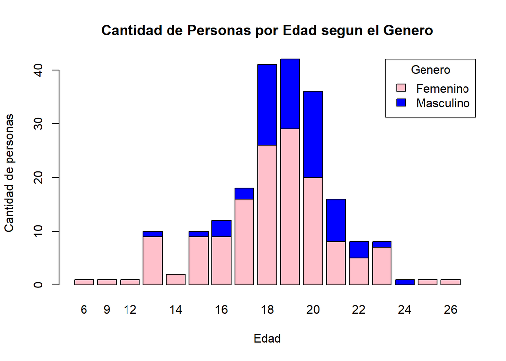

```r
barplot(Genero_Edad,main = "Cantidad de Personas por Edad segun el Genero",xlab = "Edad",ylab = "Cantidad de personas", col=c("pink","blue"))
legend(x = "topright", legend = c("Femenino", "Masculino"), fill = c("pink", "blue"),
       title = "Genero")
```

Según los resultados de la primera gráfica podemos observar lo siguiente, en las cifras significativas sin importar la edad hay una predominación de población de género femenino a comparación de los de genero masculino. Recomendamos a futuros emprendimientos averiguar formas de atraer publico masculino o especializarse en productos kpop para mujeres.

Realizamos un boxplot que nos ayudara a representar la edad promedio de un seguidor

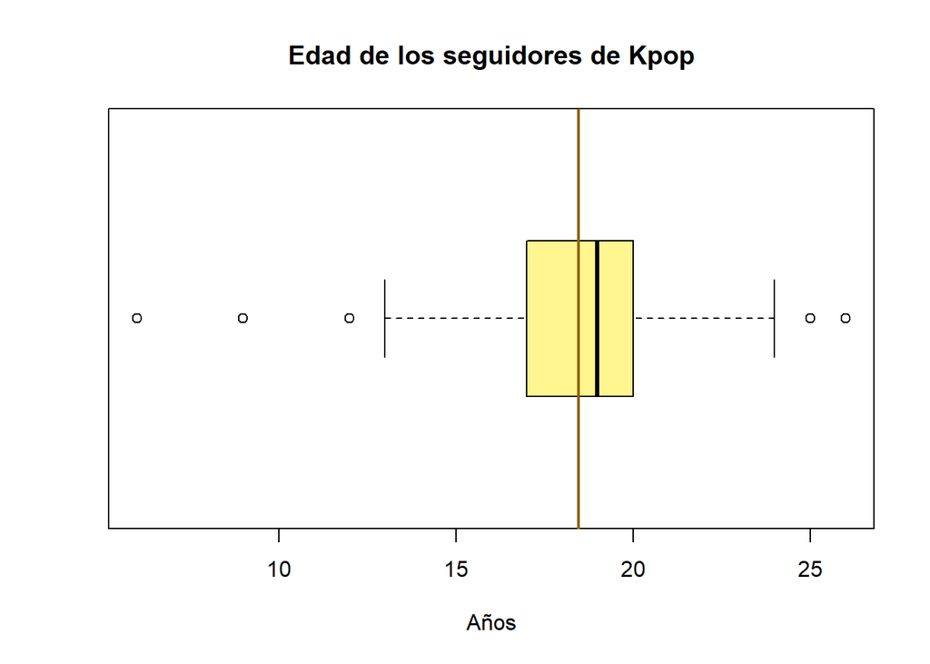

Pero si queremos ser especificos tenemos:

```r
tapply(KP$Edad,KP$Genero,mean)
```

```
##  Femenino Masculino
##  18.15172  19.18750
```

Edad de los seguidores de kpop Según los resultados de la gráfica podemos observar lo siguiente: • La media se encuentre entre 18 y 19 • La mediana se aproxima a 19 • El primer cuantil es 17 • El tercer cuantil es 20 • El IQR es igual a 3 Podemos deducir que la gran mayoría de nuestra población está en etapa de adultez temprana, los futuros emprendimientos deberán tenerlo en cuenta.

Por otro lado,en base al Segundo objetivo secundario planteamos los siguientes gráficos:

Verificamos la variable Presupuesto_prod

```r
mapply(Numericos, list(Presupuesto_productos=KP$Presupuesto_prod))
```

```
##            Presupuesto_productos
## Min        0
## Max        1e+05
## Moda       50
## Media      618.13
## Mediana    80
## Desviacion 6910.59
## Varianza   47756278
## CV         11.18
```

Hallamos un dato que se encuentra muy alejado de la realidad, procedemos a eliminarlo

```r
m<-max(KP$Presupuesto_prod)
i<-which(KP$Presupuesto_prod==m)
KP <- KP[-i,]
```

Realizamos un boxplot que nos ayudara a representar el presupuesto promedio de un seguidor

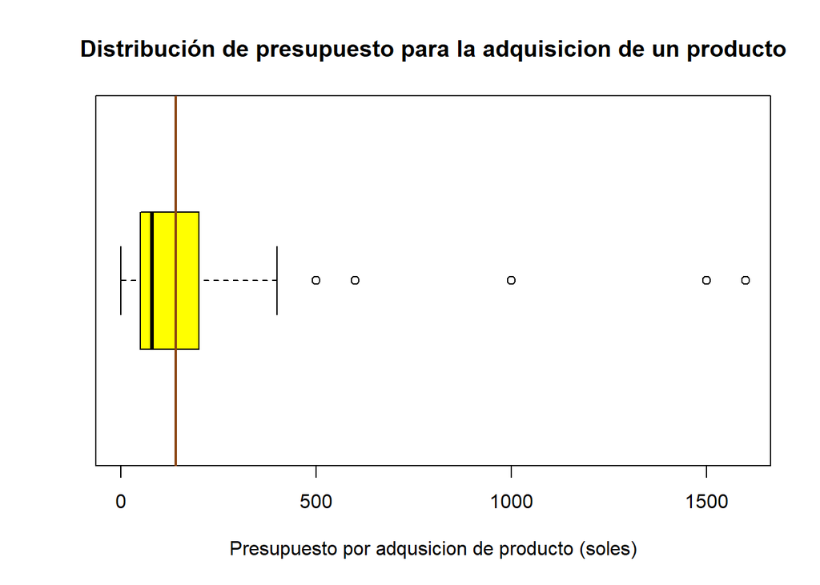

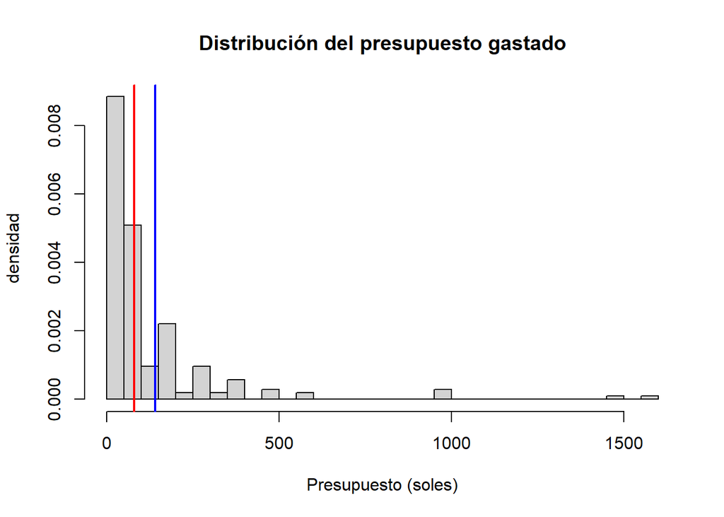

```r
hist(KP$Presupuesto_prod,breaks=30,col="lightgray",main="Distribución del presupuesto gastado",ylab="densidad",xlab="Presupuesto (soles)",prob=TRUE)
abline(v=median(KP$Presupuesto_prod),col="red",lwd=2)
abline(v=mean(KP$Presupuesto_prod),col="blue",lwd=2)
legend(200,0.012,legend=c("Mediana","Media"),lwd=2,col=c("red","blue"))
```

```r
#hist: sirve para graficar un histograma, "col" se utiliza para dar color al histograma, "main" = título, "ylab" = eje y, "xlab" = eje x,
#abline: permite colocar una linea en el histograma
#legend: leyenda, indicando primero posición por coordenadas, declaración de nombres,ancho de línea y colores
```

Según los números los números observados se recomienda a los futuros emprendimientos colocar precios dentro de esos valores para atraer la mayor cantidad de clientes posibles.

Realizamos un conteo de los fanaticos que asisten a cada lugar:

```r
sum(KP$Campo.de.Marte=="si")
```

```
## [1] 74
```

```r
sum(KP$Campo.de.Marte=="no")
```

```
## [1] 134
```

```r
sum(KP$Fiestas=="si")
```

```
## [1] 41
```

```r
sum(KP$Fiestas=="no")
```

```
## [1] 167
```

```r
sum(KP$Cines=="si")
```

```
## [1] 20
```

```r
sum(KP$Cines=="no")
```

```
## [1] 188
```

```r
sum(KP$Cafe=="si")
```

```
## [1] 26
```

```r
sum(KP$Cafe=="no")
```

```
## [1] 182
```

```r
sum(KP$CentroComercial=="si")
```

```
## [1] 22
```

```r
sum(KP$CentroComercial=="no")
```

```
## [1] 186
```

```r
sum(KP$Alameda28=="si")
```

```
## [1] 27
```

```r
sum(KP$Alameda28=="no")
```

```
## [1] 181
```

```r
sum(KP$No.asiste=="si")
```

```
## [1] 94
```

```r
sum(KP$No.asiste=="no")
```

```
## [1] 113
```

Realizamos un grafico en base a los datos obtenidos

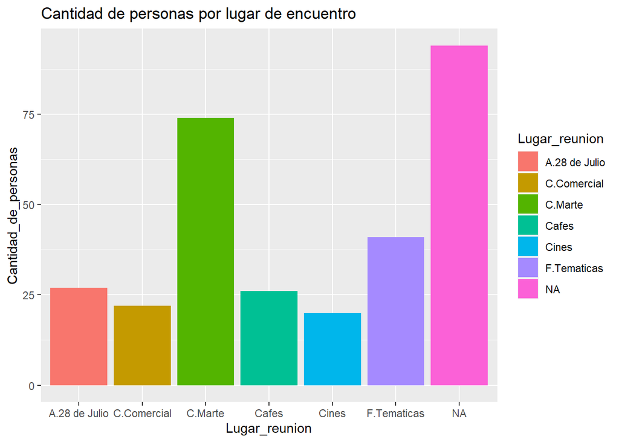

```r
library(ggplot2)

# creating a dummy dataset
Cantidad_de_personas <- c(74,41,20,26,22,27,94)

Lugar_reunion <- c("C.Marte","F.Tematicas","Cines","Cafes","C.Comercial","A.28 de Julio","NA")

# creating data frame
circle <- data.frame(Lugar_reunion,Cantidad_de_personas)

# creating plot using the above data
ggplot(circle, aes(Lugar_reunion,Cantidad_de_personas,fill=Lugar_reunion)) +
  geom_bar(stat="identity", position = "dodge") +
  labs(title="Cantidad de personas por lugar de encuentro")
```

Según los resultados de la gráfica observamos una gran cantidad de personas de nuestra población no asiste a reuniones con otros grupos. Dentro de los lugares favoritos para reunirse campo de marte es el preferido por nuestra población, seguido de las fiestas temáticas. Por último, se observa que no hay predominancia dentro del resto de lugares. Como recomendación a futuros emprendimientos y tratar de ubicarse cerca al campo de marte.

En base al Tercer Objetivo Secundario:

Realizamos un conteo de los medios que utilizan los fanaticos:

```r
sum(KP$television=="si")
```

```
## [1] 13
```

```r
sum(KP$television=="no")
```

```
## [1] 195
```

```r
sum(KP$PaginasWeb=="si")
```

```
## [1] 65
```

```r
sum(KP$PaginasWeb=="no")
```

```
## [1] 143
```

```r
sum(KP$Redes=="si")
```

```
## [1] 181
```

```r
sum(KP$Redes=="no")
```

```
## [1] 27
```

```r
sum(KP$youtube=="si")
```

```
## [1] 122
```

```r
sum(KP$youtube=="no")
```

```
## [1] 86
```

```r
sum(KP$radio=="si")
```

```
## [1] 7
```

```r
sum(KP$radio=="no")
```

```
## [1] 201
```

```r
sum(KP$circulo=="si")
```

```
## [1] 45
```

```r
sum(KP$circulo=="no")
```

```
## [1] 163
```

```r
sum(KP$paneles=="si")
```

```
## [1] 2
```

```r
sum(KP$paneles=="no")
```

```
## [1] 206
```

Realizamos un grafico en base a los datos obtenidos

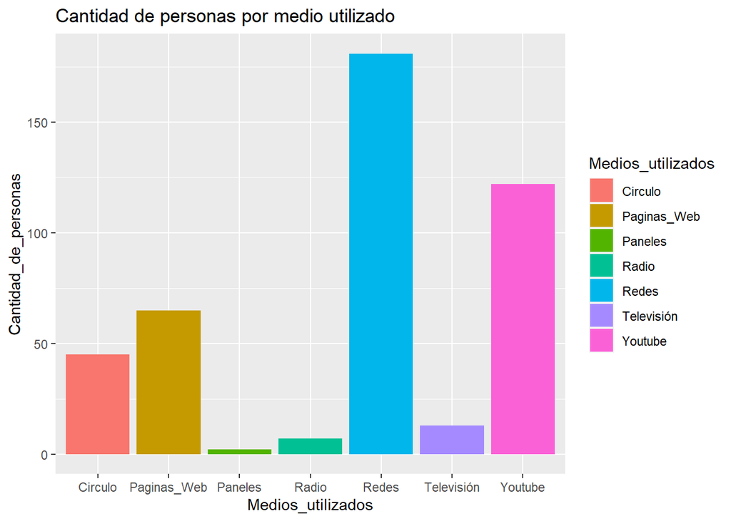

```r
library(ggplot2)

# creating a dummy dataset
Cantidad_de_personas <- c(13,65,181,122,7,45,2)

Medios_utilizados <- c("Televisión","Paginas_Web","Redes","Youtube","Radio","Circulo","Paneles")

# creating data frame
circle <- data.frame(Medios_utilizados,Cantidad_de_personas)

# creating plot using the above data
ggplot(circle, aes(Medios_utilizados,Cantidad_de_personas,fill=Medios_utilizados)) +
  geom_bar(stat="identity", position = "dodge") +
  labs(title="Cantidad de personas por medio utilizado")
```

Según los resultados obtenidos que la mayor parte de nuestra población se informa a través de alguna red social. Por lo tanto, como recomendación para futuros emprendimientos se sugiere hacer campañas a través de redes para llegar a una mayor parte de la comunidad kpop y así poder difundir sus productos.

### Casos especiales

Adicional a los objetivos planteados, también es importante conocer la principal razón por la que un fan de K_pop sigue a sus Idols dentro de esta comunidad. Para ello, se hizo uso del siguiente gráfico de barras:

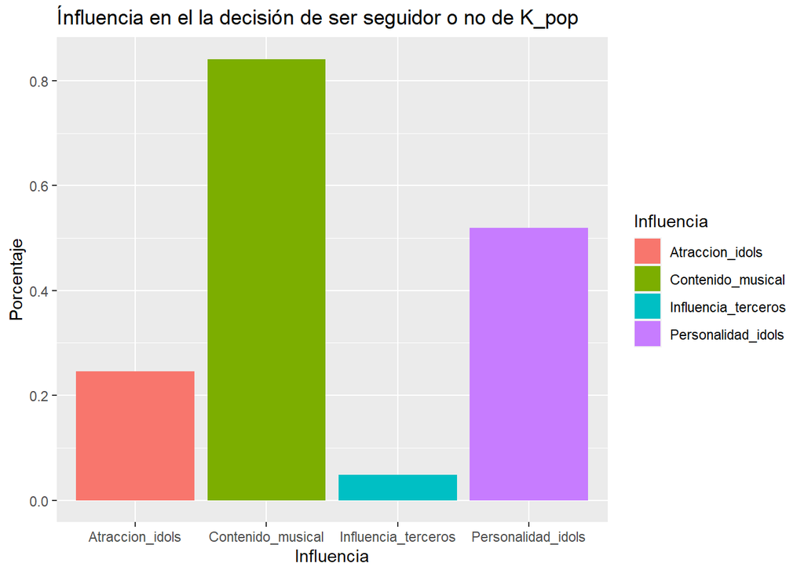

```r
library(ggplot2)

# creating a dummy dataset
Porcentaje <- c(175,108,10,51)/nrow(KP)

Influencia <- c("Contenido_musical","Personalidad_idols","Influencia_terceros","Atraccion_idols")

# creating data frame
circle <- data.frame(Porcentaje,Influencia)

# creating plot using the above data
ggplot(circle, aes(Influencia, Porcentaje,fill=Influencia)) +
  geom_bar(stat="identity", position = "dodge") +
  labs(title="Ínfluencia en el la decisión de ser seguidor o no de K_pop ")
```

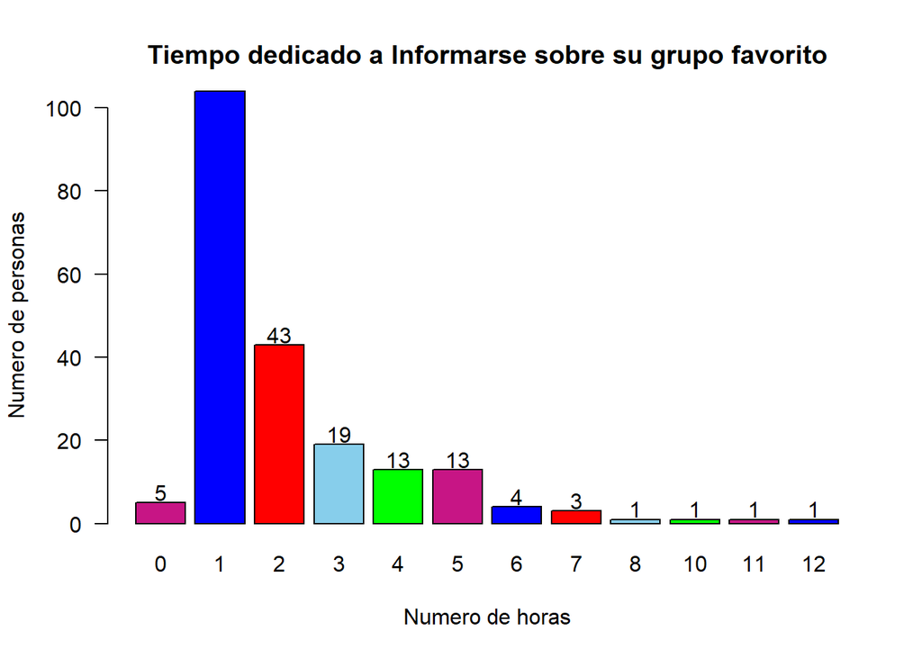

En base a este grafico podemos deducir que el mayor numero de personas dedican por lo menos 1 hora a informarse sobre el genero K-POP.

```r
mean(KP$Tiempo_dedicado)
```

```
## [1] 2.163462
```

Siendo el promedio de horas dedicadas de 2,16 horas.

Analizando los siguientes datos

```r
summary(lm(KP$Importancia~KP$Edad))
```

```
##
## Call:
## lm(formula = KP$Importancia ~ KP$Edad)
##
## Residuals:
##     Min      1Q  Median      3Q     Max
## -2.7039 -0.7038  0.2962  1.0960  1.4212
##
## Coefficients:
##             Estimate Std. Error t value Pr(>|t|)
## (Intercept)  4.15409    0.51772   8.024 7.66e-14 ***
## KP$Edad     -0.02501    0.02776  -0.901    0.369
## ---
## Signif. codes:  0 '***' 0.001 '**' 0.01 '*' 0.05 '.' 0.1 ' ' 1
##
## Residual standard error: 1.06 on 206 degrees of freedom
## Multiple R-squared:  0.003926,   Adjusted R-squared:  -0.0009094
## F-statistic: 0.8119 on 1 and 206 DF,  p-value: 0.3686
```

Esto nos indica que no hay una relacion directa entre el nivel de importancia y la edad de un seguidor de K-POP, por tanto el nivel de importancia varia de forma aleatoria a la edad que un seguidor posea.

Finalmente, se decidió analizar el nivel de importancia que tiene el K_pop en los seguidores de este género. Así, se hizo un gráfico de mozaico para analizar esta característica de esta población:

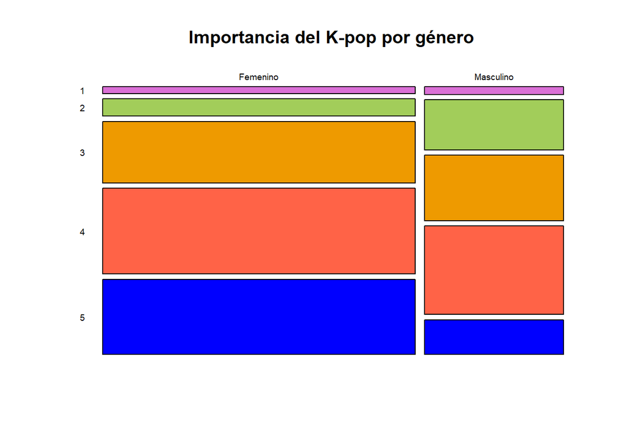

Del gráfico claramente se observa que, en comparación a varones, un mayor porcentaje de mujeres seguidoras de K_pop atribuyen a este género un nivel de importancia 5. Por otro lado, respecto al comportamiento de los seguidores de K_pop, en comparación a las de género femenino, un mayor porcentaje de varones seguidores de K_pop atribuye a este género un nivel de importancia de 2.

# Analisis Probabilistico

## Objetivos

Los objetivos planteados para trabajar la parte probabilistica del proyecto son:

- Determinar los productos y los lugares con mayor frecuencia de reuniones de seguidores de grupos kpop en relación con género y presupuesto con el propósito de brindar a nuevos emprendimientos posibles lugares donde poder ubicarse.
- Determinar los medios más usados de esta comunidad por los cuales se enteran de eventos kpop con el propósito de brindar a nuevos emprendimientos un panorama de cuáles son los medios de información por los cuales se pueden difundir sus productos.

## Preguntas de Probabilidades

En base a los datos recolectados, podemos plantear las siguientes preguntas a analizar:

Antes de empezar necesitamos conocer el numero de varones y mujeres seguidoras de k-Pop.

### Porcentaje de mujeres y varones presentes en el estudio

```r
DF1<-data.frame(table(KP$Genero))
```

```r
P_muj=DF1[1,2]/(DF1[1,2]+DF1[2,2])

cat('El porcentaje de mujeres del total de encuestados es ',P_muj*100,'%. Por otro lado, el porcentaje de varones del total de encuestados es ',(1-P_muj)*100,'%')
```

```
## El porcentaje de mujeres del total de encuestados es  69.23077 %. Por otro lado, el porcentaje de varones del total de encuestados es  30.76923 %
```

Estos resultados pueden ser plasmados en el siguiente gráfico:

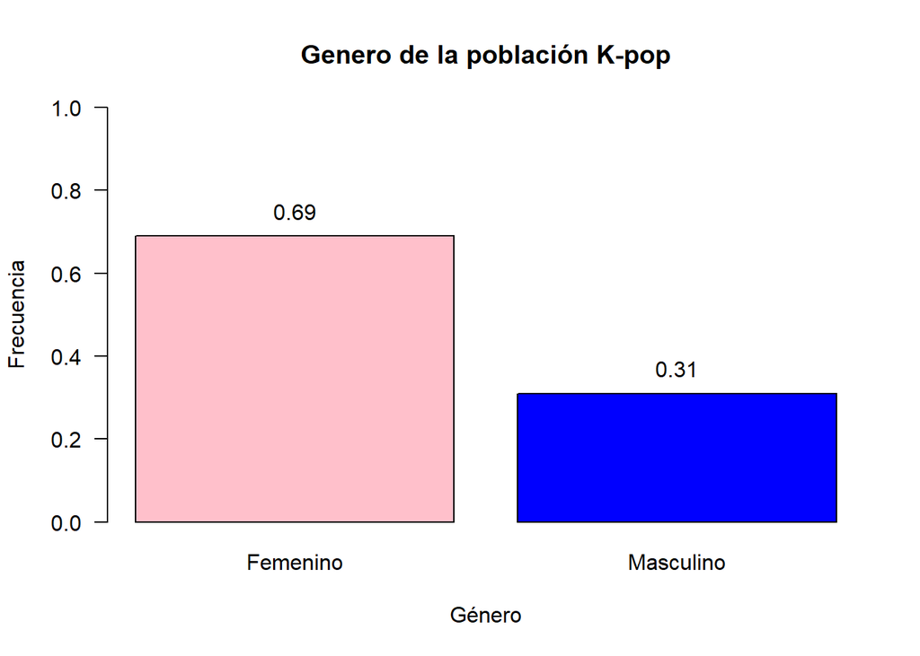

```r
redondear(table(KP$Genero)/nrow(KP))-> Genero
xx<-barplot(Genero,las=1,ylim = c(0,1),main = "Genero de la población K-pop",xlab = "Género",ylab = "Frecuencia", col=c("pink","blue","orange"))
text(xx, Genero+.06, labels = Genero)
```

Con estos valores, se procede a realizar el análisis probabilístico:

## SIMPLE

#### 1. Dado que el 69.23% de seguidores del género K-POP son del género femenino, se desea saber cuán probable es que un seguidor de K_pop perteneciente a este género use como medio principal de información Youtube.

```r
DF_MI<-data.frame(table(KP$Genero,KP$youtube))
P_MY=DF_MI[3,3]/(DF_MI[3,3]+DF_MI[1,3])
cat('La probabilidad de que un seguidor de K_pop perteneciente al genero femenino use como medio principal de informacion Youtube es',P_MY*100,'%. Asi, el ',(1-P_MY)*100,'% de ellas prefiere otros medios de informacion')
```

```
## La probabilidad de que un seguidor de K_pop perteneciente al genero femenino use como medio principal de informacion Youtube es 61.11111 %. Asi, el  38.88889 % de ellas prefiere otros medios de informacion
```

```r
KP %>% mutate(No.asiste=
        ifelse(No.asiste %in% c("n"), "no",No.asiste
         )) -> KP
```

```r
DF_NE<-data.frame(table(KP$Genero,KP$No.asiste))
P_NE=DF_NE[2,3]/(DF_NE[2,3]+DF_NE[4,3])
cat('La probabilidad de que un seguidor de K_pop masculino no asista a ningun lugar de encuentro es: ',P_NE*100,'%')
```

```
## La probabilidad de que un seguidor de K_pop masculino no asista a ningun lugar de encuentro es:  51.5625 %
```

## UNION

#### 3. Se desea conocer qué tan probable es que un seguidor de K_pop prefiera informarse sobre su grupo favorito por medio de redes sociales o youtube.

```r
A<-filter(KP,Redes=="si")
B<-filter(KP,youtube=="si")
C<-filter(A,youtube=="si")

nrow(A)
```

```
## [1] 181
```

```r
nrow(B)
```

```
## [1] 122
```

```r
nrow(C)
```

```
## [1] 102
```

```r
nrow(KP)
```

```
## [1] 208
```

```r
library(VennDiagram)
```

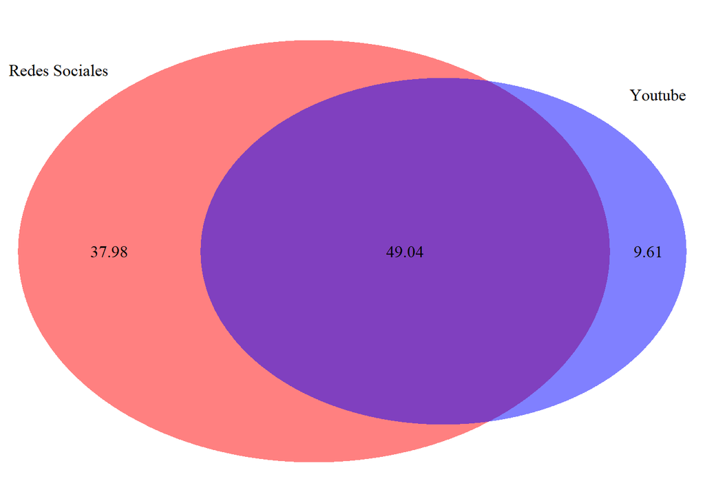

```
## (polygon[GRID.polygon.323], polygon[GRID.polygon.324], polygon[GRID.polygon.325], polygon[GRID.polygon.326], text[GRID.text.327], text[GRID.text.328], text[GRID.text.329], text[GRID.text.330], text[GRID.text.331])
```

```r
grid.newpage()
draw.pairwise.venn(area1=round(nrow(A)*100/nrow(KP),digits = 2),
                   area2=round(nrow(B)*100/nrow(KP),digits = 2),
                   cross.area=round(nrow(C)*100/nrow(KP),digits = 2),
                   col = 'red',
                   lty="blank",
                  fill = c("red","blue"),
                  category = c("Redes Sociales","Youtube"),
                  cex = 1,
                    cat.cex = 1,
                  cat.just=list(c(0.5, -2), c(0.5, -2)),
                  ind = TRUE)
```

```r
cat('La probabilidad de que un seguidor de K_pop prefiera informarse sobre su grupo favorito por medio de redes sociales o youtube es : 96.63 %, lo que indica que un 3.37% de los encuestados no prefiere ninguno de estos dos medios para informarse respecto a la cultura K_pop')
```

```
## La probabilidad de que un seguidor de K_pop prefiera informarse sobre su grupo favorito por medio de redes sociales o youtube es : 96.63 %, lo que indica que un 3.37% de los encuestados no prefiere ninguno de estos dos medios para informarse respecto a la cultura K_pop
```

## INTERSECCION

#### 4. En base a nuestro estudio obtuvimos que el grupo más seguido es BTS, por ello queremos saber qué tan probable es que un seguidor de BTS, se reúna en campo de marte y en un Centro Comercial.

```r
KP_BTS<-filter(KP,GrupoFav=='BTS')
FIL<-KP_BTS %>% filter(Campo.de.Marte=='si'& CentroComercial=='si')
CM<-filter(KP,Campo.de.Marte=='si')
CC<-filter(KP,CentroComercial=='si')
```

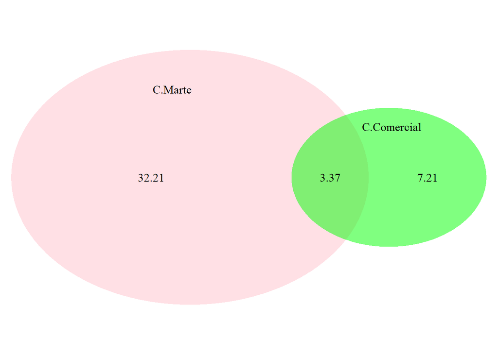

```
## (polygon[GRID.polygon.332], polygon[GRID.polygon.333], polygon[GRID.polygon.334], polygon[GRID.polygon.335], text[GRID.text.336], text[GRID.text.337], text[GRID.text.338], text[GRID.text.339], text[GRID.text.340])
```

```r
grid.newpage()
draw.pairwise.venn(area1=round(nrow(CM)*100/nrow(KP),digits = 2),
                   area2=round(nrow(CC)*100/nrow(KP),digits = 2),
                   cross.area=round(nrow(FIL)*100/nrow(KP),digits = 2),
                   col = 'red',
                   lty="blank",
                  fill = c("pink","green"),
                  category = c("C.Marte","C.Comercial"),
                  cex = 1,
                    cat.cex = 1,
                  cat.just=list(c(-3, 1), c(2, 1)),
                  ind = TRUE)
```

# CASOS DE TEOREMA DE BAYES

### PROBLEMA 1

Lo primero que se hará es plantear el diagrama de árbol para tener una visión mas clara de los datos

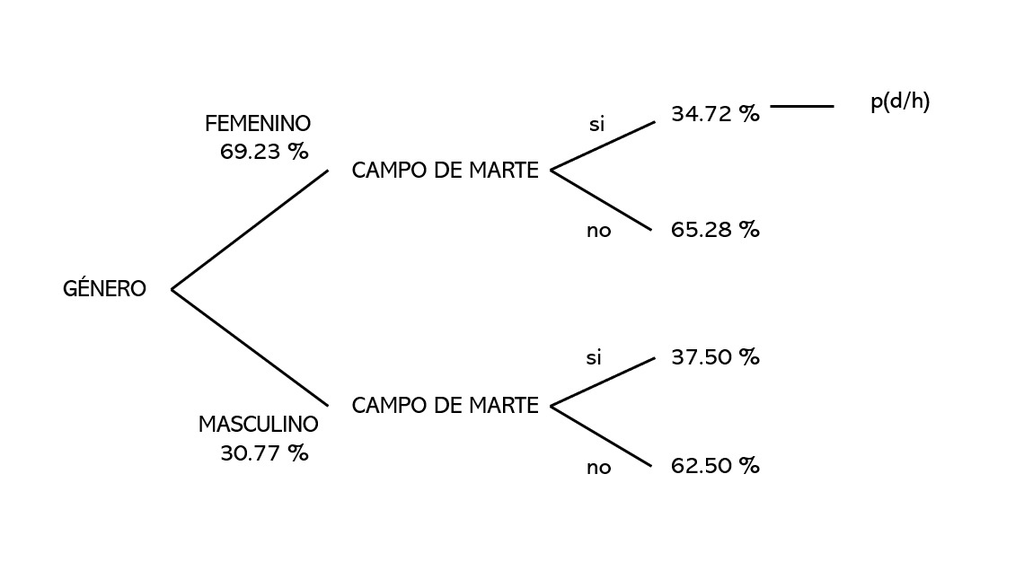

**Figura 4:Diagrama del Arbol**

### Item a.

Como se puede observar en este diagrama, el porcentaje de mujeres que hay p(m) es el 69.23 % (0.6923),asimismo observamos que el porcentaje de mujeres que asisten al campo de marte p(m|c) es el 34.72 %(0.3472).

```r
p_m = 0.6923
p_mc = 0.3472
```

Para poder obtener la probabilidad planteada tendremos que multiplicar los dos valores obtenidos:

```r
prob_1=p_m*p_mc
prob_1
```

```
## [1] 0.2403666
```

```r
cat('Es asi que obtenemos que la probabilidad que una seguidora de K-Pop opte como lugar de encuentro el Campo de Marte es del',prob_1*100,"%")
```

```
## Es asi que obtenemos que la probabilidad que una seguidora de K-Pop opte como lugar de encuentro el Campo de Marte es del 24.03666 %
```

### Item b

A travez del diagrama podemos obtener que el 69.231% son mujeres y que de este grupo el 65.28% no prefiere reunirse en el campo de marte, por otro lado tambien observamos que el 30.769% son varones y que el 62.5% de ellos no prefieren reunirse en el campo de marte.

```r
p_m=0.69231
p_mnc=0.6528
p_h=0.30769
p_hnc=0.625
```

Para poder obtener la probabilidad planteada tendremos que multiplicar la probabilidad en mujeres y sumarla con la de varones.

```r
prob_2=(p_m*p_mnc)+(p_h*p_hnc)
prob_2
```

```
## [1] 0.6442462
```

```r
cat('Es asi que obtenemos que la probabilidad de escoger al azar un seguidor de K-Pop que no opte como lugar de encuentro el Campo de Marte es del',prob_2*100,"%")
```

```
## Es asi que obtenemos que la probabilidad de escoger al azar un seguidor de K-Pop que no opte como lugar de encuentro el Campo de Marte es del 64.42462 %
```